# Taller 1 Simulación

2022-03-11

1. Al comparar los caracteres morfométricos de una especie de langostinos de gran importancia económica en Argentina se observaron diferencias de tamaño entre macho y hembra. En la siguiente tabla se presentan los datos (Largo total mm) de las morfometrías de machos y hembras obtenidos en diferentes recolectas (Ruiz & Mendia, 2008).

|  | Machos |  |
| --- | --- | --- |
| 140.9 | 173.9 | 118.9 |
| 121.7 | 177.4 | 140.0 |
| 173.8 | 154.8 | 192.7 |
| 154.5 | 177.5 | 134.4 |
| 109.2 | 153.4 | 175.0 |
| 150.7 | 138.7 | 169.8 |
| 203.3 | 136.7 | 153.9 |
| 163.0 | 165.3 | 176.7 |
| 137.7 | 126.7 | 150.0 |

|  | Hembras |  |
| --- | --- | --- |
| 183.2 | 182.5 | 166.8 |
| 184.1 | 190.0 | 196.3 |
| 183.0 | 178.1 | 193.3 |
| 204.3 | 193.2 | 187.3 |
| 176.5 | 180.4 | 185.8 |
| 179.0 | 184.3 | 189.3 |
| 188.3 | 189.2 | 195.5 |
| 186.8 | 189.1 | 202.4 |
| 202.2 | 203.1 | 210.8 |

1. Haga un histograma con cinco clases y determine la distribución de los datos para cada sexo. Explique acerca de la distribución del tamaño para cada género.

Para el macho tenemos la siguiente distribución

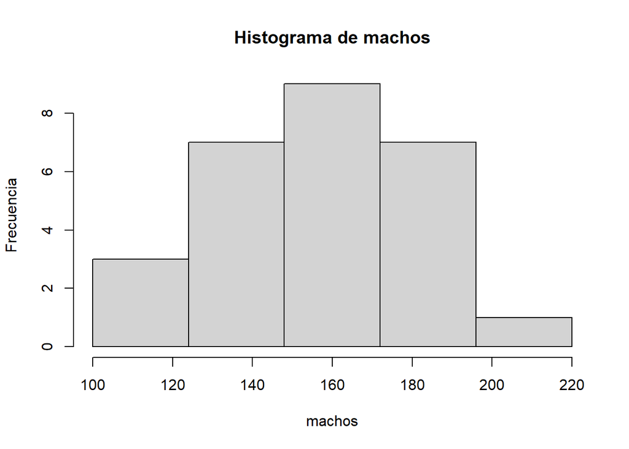

Como se puede observar en el histograma de los machos se puede afirmar que estos datos tienen un comportamiento de una distribución normal

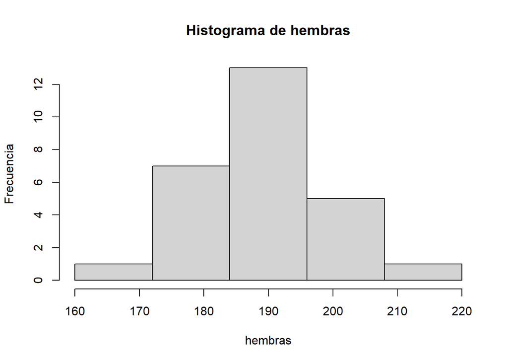

Como se puede observar en el histograma de los datos para las hembras tambien se tiene un comportamiento de una distribución normal pero a diferencia de los machos esta tiene los datos mas concentrados en la media

A continuación se tiene el promedio y la desviación estándar para los machos

```
## [1] 154.4667
```

```
## [1] 23.06462
```

Para los machos la desviacion estandar esta un poquito alta en comparacion las hembras, y se puede afirmar que en promedio los machos son mas pequeños que las hembras

A continuación se tiene el promedio y la desviación estándar para las hembras

```
## [1] 189.0667
```

```
## [1] 9.831151
```

En las hembras se puede ver que en promedio son mas grandes que los machos y tiene los datos mas concentrados esto debido a que su desviación estandar es mas pequeña que la de los machos

Se tiene que para el intervalo de confianza del 97 % de los machos es:

```
## [1] 144.8341 164.0992
```

Se tiene que para el intervalo de confianza del 97 % de las hembras es:

```
## [1] 184.9608 193.1725
```